# Homework 4

2/13/2025

Kaustubh Duddala [Github](https://github.com/kaustubhduddala/StatisticsAndDataScience/tree/main/SDS%20315/Homework%204)

## Problem 1

Are the observed data (70 flagged trades out of 2021) consistent with the SEC’s null hypothesis that, over the long run, securities trades from the Iron Bank are flagged at the same 2.4% baseline rate as that of other traders?

#### Iron Bank

```
## p value: 0.0015
```

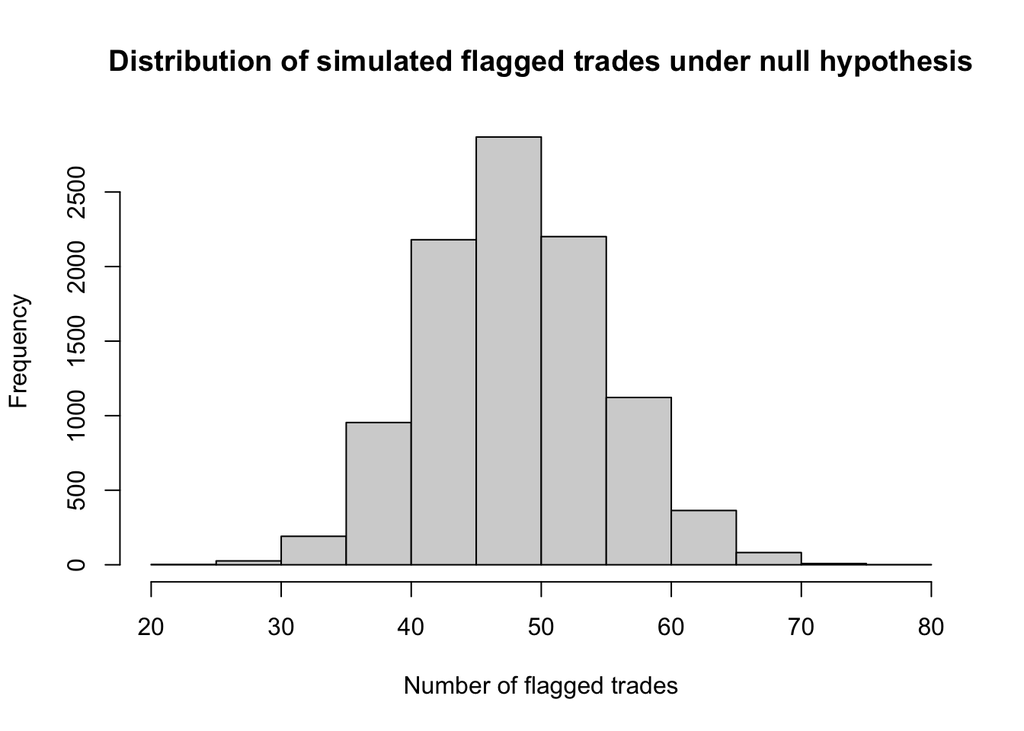

## Problem 2

Are the observed data for Gourmet Bites consistent with the Health Department’s null hypothesis that, on average, restaurants in the city are cited for health code violations at the same 3% baseline rate?

#### Health Inspections

```
## P value: 1e-04
```

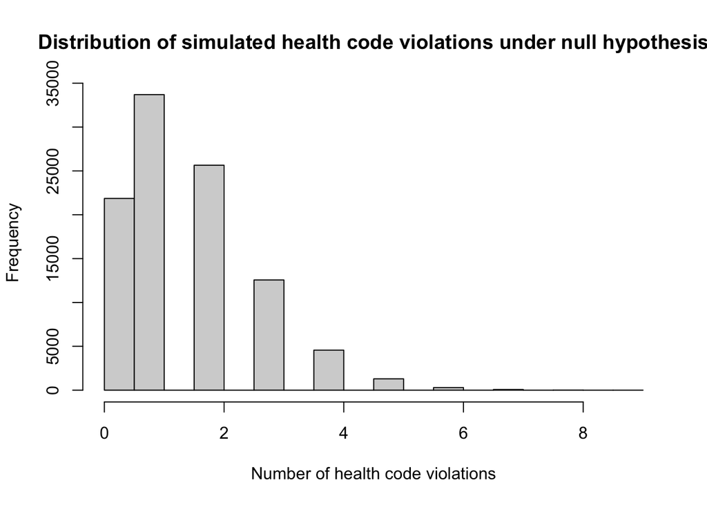

## Problem 3

Determine whether the distribution of jurors empaneled by this judge is significantly different from the county’s population proportions. If so, does this suggest systematic bias in jury selection? What other explanations might exist, and how could you investigate further?

```
##
##  Chi-squared test for given probabilities
##
## data:  observed_counts
## X-squared = 12.426, df = 4, p-value = 0.01445
```

```
## P-value: 0.0144468
```

The null hypothesis is that the jury selection reflects the county’s population proportions. The test statistic is the Chi-squared statistic. The p-value is 0.01445. Based on this p-value, the null hypothesis is rejected. If significant, it suggests bias, but other explanations could include random variation or differences in exemption rates. Further investigation could involve analyzing data from other judges and examining the reasons for juror excusals.

## Problem 4

One was generated by an LLM with a watermark based on a frequency shift idea. Can you tell which sentence it is?

#### Part A: the null or reference distribution

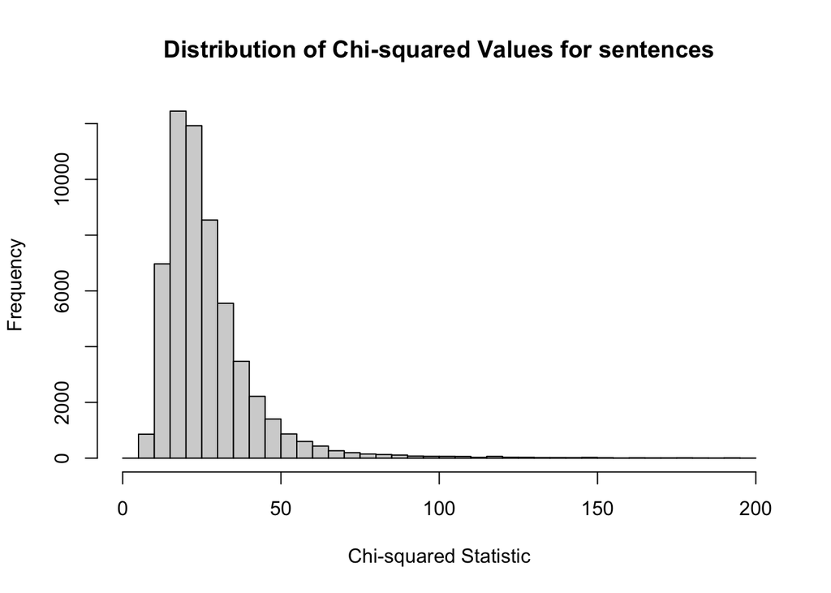

#### Part B: checking for a watermark

```
## # A tibble: 10 × 3
##    Sentence Chi_Squared P_value
##       <int>       <dbl> <chr>
##  1        1        22.9 0.513
##  2        2        13.1 0.926
##  3        3        46.3 0.076
##  4        4        23.5 0.489
##  5        5        23.7 0.484
##  6        6        96.5 0.009
##  7        7        28.3 0.328
##  8        8         9.6 0.988
##  9        9        44.9 0.084
## 10       10        50   0.059
```

The results strongly indicate that Sentence 6 contains an LLM watermark. Its letter frequency distribution deviates significantly from natural English patterns, a sign of algorithmic text generation with frequency-based watermarks.